# Racial inequality in Philadelphia

Sam Zielinski

The city of Philadelphia is an interesting area, as there are areas of high wealth and poverty in such close proximity to each other. This project explores the inequality in wealth and how it relates to race in Philadelphia, Camden, and Wilmington. It looks at differences in income based on racial indentity as well as on location. It aslo looks at the distribution of different racial indentities across different nieghborhoods.

```r
tracts <- read_csv("https://raw.githubusercontent.com/statsmaths/stat_data/gh-pages/acs_tract_data_2016.csv.gz")
camden <- filter(tracts, cbsa == "Philadelphia-Camden-Wilmington, PA-NJ-DE-MD")
```

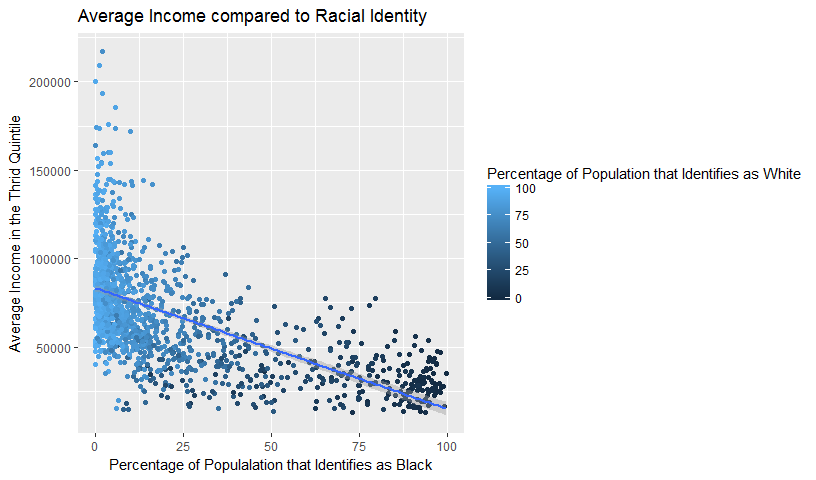

```r
ggplot(camden, aes(race_black, hh_income_q3)) +
  geom_point(aes(color = race_white)) +
  stat_smooth(method = lm) +
  xlab("Percentage of Populalation that Identifies as Black") +
  ylab("Average Income in the Thrid Quintile") +
  ggtitle("Average Income compared to Racial Identity") +
  labs(color = "Percentage of Population that Identifies as White")
```

The first graph shows how the percentage of residents who identify as black compares to the average income in the third quintile. The third quintile was chosen because its represent the median. The color gradient, in contrast, show the percentage of the population that identifies as white. The graph shows a clear trend that the more of the population that identifies as black correlates to a lower average income. Likewise, the higher the percentage of the population that identifies as white correlates to a higher average income, showing that minorities are more disposed to being impoverished. This data gives a clear image of the inequality with respect to wealth and racial identity.

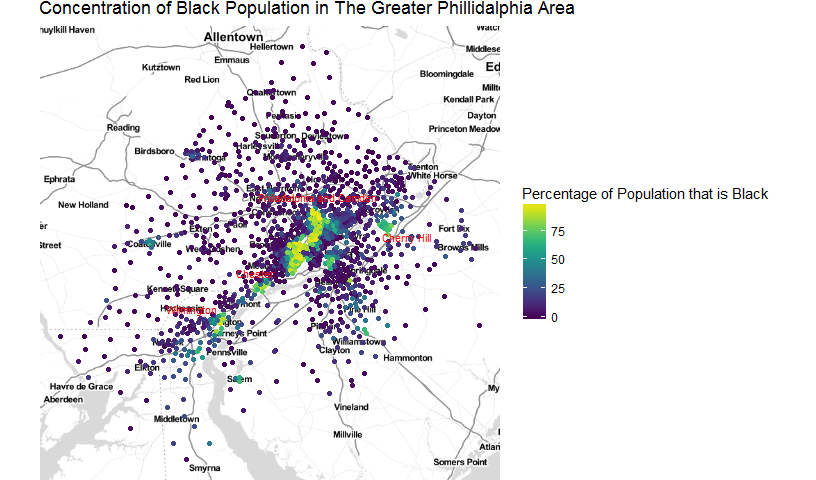

```r
qmplot(lon, lat, data = camden, geom = "blank") +
  geom_point(aes(color = race_black)) +
  annotate("rect", xmin = -75.28, xmax = -75.05, ymin = 39.88, ymax = 40.1, fill = "purple", alpha = 0.0) +
  labs(color = "Percentage of Population that is Black") +
  annotate("text", x = -74.8, y = 40, label = "Cherry Hill", size = 3, color = "red") +
  annotate("text", x = -75.15, y = 40.12, label = "Philadelphia and Camden", size = 3, color = "red") +
  annotate("text", x = -75.4, y = 39.89, label = "Chester", size = 3, color = "red") +
  annotate("text", x = -75.65, y = 39.78, label = "Wilmington", size = 3, color = "red") +
  ggtitle("Concentration of Black Population in The Greater Phillidalphia Area") +
  scale_color_viridis()
```

```r
NA
```

The data only show the inequality in income however, does not show the entire story. Another major factor in the inequality and wealth distribution here is location. The next graph plots each neighborhood on a map of the entire area and shows areas of higher black population as a color gradient. What is immediately apparent is that distribution of neighborhoods with a high number of people who identify as black is not random. The areas of Cherry Hill, North Philly, West/Southwest Philly, Camden, Chester, and Wilmington have much higher concentrations of people who identify as black. It is also worth noting that there is a not a gradual gradient between the areas that are predominantly black and the areas that are predominantly white. Right next to North and Southwest Philly are dark spots at Northwest and Center Philly, as well as a dark spot in the suburbs south of Camden and Cherry Hill, in the area of Moorestown and Haddonfield. This is interesting because it shows a clear divide between the two populations.

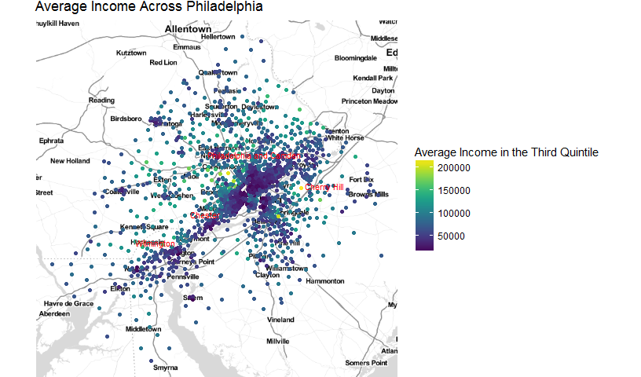

```r
qmplot(lon, lat, data = camden, geom = "blank") +
  geom_point(aes(color = hh_income_q3)) +
  annotate("text", x = -74.8, y = 40, label = "Cherry Hill", size = 3, color = "red") +
  annotate("text", x = -75.15, y = 40.12, label = "Philadelphia and Camden", size = 3, color = "red") +
  annotate("text", x = -75.4, y = 39.89, label = "Chester", size = 3, color = "red") +
  annotate("text", x = -75.65, y = 39.78, label = "Wilmington", size = 3, color = "red") +
  ggtitle("Average Income Across Philadelphia") +
  labs(color = "Average Income in the Third Quintile") +
  scale_color_viridis()
```

The third graph further explores the importance of location in the divide between the two populations. The third graph shows the average income of each neighborhood graphed over a map of the entire area. The data combines the conclusions of the first and second graphs to show how the areas with higher concentration of black identifying population have a lower average income. There are hot spots for high income in the predominantly white neighborhoods of Moorestown/Haddonfield, south of Cherry Hill and Camden, Northwest Philadelphia, and Center city. It makes sense that Center city would have high income, as it is the corporate center of a major city. The areas of Northwest Philly and Moorestown, however, have no corporate or manufacturing headquarters, but they are within a short and easy commute of Philadelphia, and are popular neighborhoods for the wealthier people who work in the city. This explains why some of the areas have more wealth, but it does not explain why areas of poverty are in such close proximity?

## Conclusion

The plight of Camden is complicated, however its demise, according to an article by Mel Evans, dates back to the 1960’s. From the second it started to decline the city has been plagued by corruption from its local government, leaving it to nothing but a downward spiral. What is important in this is that as Camden declined, the middle class escaped to the surrounding suburbs, which allowed them to flourish as the middle class helped pump money into them and the local businesses, all while Camden continued to lose money and industry (Evans, 2013). The same idea can be seen in Northwest Philadelphia. During the Great Depression and the 1950’s, as African Americans moved into the neighborhoods of North and Southwest Philly, there was an exodus of the middle class, which was mostly white at this point in history, towards nicer suburbs in Northwest Philadelphia. As time went on societal institutions perpetuated this inequality and caused the separation we see in the data today. Overall, the data shows that there is a very clear barrier between the white and black populations in the greater Philadelphia area. There is an apparent income difference as well as very clear divide in where each population lives. Furthermore, the average income of each neighborhood corresponds to the racial demographics of each neighborhood. This means that there is indeed racial inequality in Philadelphia, in terms of wealth and location.

## References

Evans, Mel. “Why Camden, NJ, is Still Failing Despite State Intervention”. Governing.com. 2013.